# Exercice 2 - Test de Student pour un échantillon

Statistiques avancées en sciences humaines et sociales

07/02/2019

## Exercice 2

Une usine fabrique des billes métalliques. L’usine s’est engagée à fournir à un client des billes dont le diamètre moyen est de 25 milimètres. Le client réceptionne sa commande. Dans le lot reçu, il prélève un échantillon de 20 billes choisies au hasard et mesure les diamètres en milimètres suivantes:

24,7 24,9 25,0 25,0 25,1 25,1 25,1 25,2 25,3 25,4

24,8 24,9 25,0 25,0 25,1 25,1 25,2 25,3 25,3 25,5

On suppose que le diamètre en millimètres de ces billes est une var X suivant une loi normale. A partir de ces données, peut-on affirmer que l’usine ne respecte pas ss engagements ? Faire un test statistique adapté au risque 5%.

## Réponse

Hypothèse

H0: $\mu=25$ H1: $\mu \ne 25$

On utilise un test de student. Il est bilatéral.

On a $\mu_0 = 25$, $\bar{x} = 25,1$ et $s=0.2$.

Pour calculer $\bar{x}$ et $s$, j’ai utilisé R-logiciel.

```r
a<-c(24.7  , 24.9,  25.0,  25.0,  25.1 , 25.1,  25.1,  25.2,  25.3,
     25.4, 24.8  , 24.9 , 25.0 , 25.0 , 25.1 , 25.1 , 25.2  ,25.3  ,25.3  ,25.5 ) # données
mean(a) # moyenne
```

```
## [1] 25.1
```

```r
sd(a) # écart-type
```

```
## [1] 0.2
```

$t_{obs}=\frac{\bar{x}-\mu_0 }{s/\sqrt{n}}=\frac{25,1 - 25 }{0,2/\sqrt{20}}=2,2360$

Notons que avec $\alpha=0,05$, il faut déterminer le réel $t_{\alpha}(\nu)$ tel que $P(|T|\ge t_{\alpha}(\nu) )=\alpha=0,05$, où $T \sim T(\nu), \nu=n-1=20-1=19$

La table donne :

.

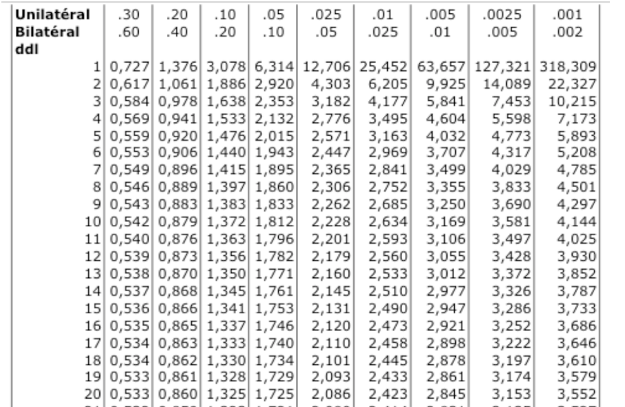

$t_{\alpha}(\nu)=2,093$

Comme $|t_{obs}|=2,2360 > 2,093$, on rejette H0.

Par conséquent, au risque 5%, on peut affirmer que l’usine n’a pas tenu son engagment.

## Analyse des résultats avec R

```r
#### t test
donnes<-c(24.7  , 24.9,  25.0,  25.0,  25.1 , 25.1,  25.1,  25.2,  25.3,
     25.4, 24.8  , 24.9 , 25.0 , 25.0 , 25.1 , 25.1 , 25.2  ,25.3  ,25.3  ,25.5 ) # données

m.theo<-25 # valeur de la moyenne théorique
t.test(donnes,mu =m.theo,alternative =c("two.sided"),conf.level =0.95)
```

```
##
##  One Sample t-test
##
## data:  donnes
## t = 2.2361, df = 19, p-value = 0.03754
## alternative hypothesis: true mean is not equal to 25
## 95 percent confidence interval:
##  25.0064 25.1936
## sample estimates:
## mean of x
##      25.1
```

Dans le résultat ci-dessus : t est la statistique de Student (t = 2,2361), df est le degré de liberté (df= 19), p-value est le degré de significativité du test (p-value = 0,03754). L’intervalle de confiance de la moyenne à 95% est également montrée (intervalle de confiance= [25.0064; 25.1936]); et enfin, on a la valeur moyenne de la série x (moyenne = 25,1).

La p-value du test est de 0,03754. Ce qui est inférieur à 0.05. On rejette l’hypothèse 0 et on conclut que l’usine n’a pas tenu son engagment avec une p-value = 0,03754.